# Zotero group APA

Published

16 October 2026

Zotero data of 16 October 2026 · IPBES Literature Report 0.4.0 · [source code on GitHub](https://github.com/IPBES-Data/IPBES.LiteratureReport)

This report shows the state of the Zotero group **APA** ([open the group in Zotero](https://www.zotero.org/groups/2333075)). It gives an overview of the literature in the group, and lists the items which should be corrected.

Each item in the lists can be opened in the Zotero **web** library or in the Zotero **app** on your computer, so that it can be corrected directly. Corrected items disappear from the lists the next time the report is updated. Some checks compare the items with [OpenAlex](https://openalex.org), an open catalogue of scholarly publications.

## Summary

[output not shown]

**Please fix**: these items contain errors. **Please check**: these items may need a correction. **For information**: no action needed unless the group uses this, e.g. tags.

## Items to fix

The lists are sorted by importance. Use the search field above a list to find an item. **web** opens the item in the Zotero web library, **app** in the Zotero app.

### Retracted publications

These publications have been retracted. Check whether they should still be cited, and mark or remove them in Zotero.

| Open in Zotero | Title | DOI |
| --- | --- | --- |
| <a href="https://www.zotero.org/groups/2333075/items/L4VHBIRC" target="_blank">web</a> &middot; <a href="zotero://select/groups/2333075/items/L4VHBIRC">app</a> | Asia’s glaciers are a regionally important buffer against drought | <a href="https://doi.org/10.1038/nature22062" target="_blank">10.1038/nature22062</a> |

### DOI points to a different publication

The DOI of these items leads to a publication with a different title or year. Usually the DOI is wrong: open the DOI to see where it leads, and correct it in Zotero. Differences of one year (e.g. published online before print) are not listed.

| Open in Zotero | Title in Zotero | Year in Zotero | The DOI leads to | Its year | DOI |
| --- | --- | --- | --- | --- | --- |
| <a href="https://www.zotero.org/groups/2333075/items/NTMQ3NAH" target="_blank">web</a> &middot; <a href="zotero://select/groups/2333075/items/NTMQ3NAH">app</a> | GEO-6 Regional Assessment for West Asia | 2016 | West Asia | 1992 | <a href="https://doi.org/10.1080/10357823.1992.9755410" target="_blank">10.1080/10357823.1992.9755410</a> |
| <a href="https://www.zotero.org/groups/2333075/items/L9LVYVNN" target="_blank">web</a> &middot; <a href="zotero://select/groups/2333075/items/L9LVYVNN">app</a> | Alpine Plant Life - Functional Plant Ecology of High Mountain Ecosystems | 2003 | Alpine Plant Life | 2003 | <a href="https://doi.org/10.1007/978-3-642-18970-8" target="_blank">10.1007/978-3-642-18970-8</a> |
| <a href="https://www.zotero.org/groups/2333075/items/DSQJUWHJ" target="_blank">web</a> &middot; <a href="zotero://select/groups/2333075/items/DSQJUWHJ">app</a> | Regreening the Bare Hills | 2011 | Regreening the Bare Hills: Tropical Forest Restoration in the Asia-Pacific Region | 2010 | <a href="https://doi.org/10.1007/978-90-481-9870-2" target="_blank">10.1007/978-90-481-9870-2</a> |
| <a href="https://www.zotero.org/groups/2333075/items/H72QB2Q6" target="_blank">web</a> &middot; <a href="zotero://select/groups/2333075/items/H72QB2Q6">app</a> | Global hot-spots of heat stress on agricultural crops due to climate change | 2013 | Global hot-spots of heat stress on agricultural crops due to climate change | 2011 | <a href="https://doi.org/10.1016/j.agrformet.2011.09.002" target="_blank">10.1016/j.agrformet.2011.09.002</a> |
| <a href="https://www.zotero.org/groups/2333075/items/LYT7F9BM" target="_blank">web</a> &middot; <a href="zotero://select/groups/2333075/items/LYT7F9BM">app</a> | Impacts and management of wild pigs <i> <span style="font-variant:small-caps;">S</span> us scrofa </i> in <span style="font-variant:small-caps;">A</span> ustralia | 2014 | Impacts and management of wild pigs S us scrofain A ustralia | 2013 | <a href="https://doi.org/10.1111/mam.12011" target="_blank">10.1111/mam.12011</a> |
| <a href="https://www.zotero.org/groups/2333075/items/E6TU8MZ2" target="_blank">web</a> &middot; <a href="zotero://select/groups/2333075/items/E6TU8MZ2">app</a> | Global Change and Mountain Regions: An Overview of Current Knowledge | 2005 | Global Change and Mountain Regions | 2005 | <a href="https://doi.org/10.1007/1-4020-3508-x" target="_blank">10.1007/1-4020-3508-x</a> |
| <a href="https://www.zotero.org/groups/2333075/items/T33VR7LG" target="_blank">web</a> &middot; <a href="zotero://select/groups/2333075/items/T33VR7LG">app</a> | Are invasive species drivers of native species decline or passengers of habitat modification? A case study of the impact of the common myna ( <i> <span style="font-variant:small-caps;">A</span> cridot… | 2014 | Are invasive species drivers of native species decline or passengers of habitat modification? A case study of the impact of the common myna ( A cridotheres tristis) on A ustralian bird species | 2013 | <a href="https://doi.org/10.1111/aec.12049" target="_blank">10.1111/aec.12049</a> |
| <a href="https://www.zotero.org/groups/2333075/items/X992SYFZ" target="_blank">web</a> &middot; <a href="zotero://select/groups/2333075/items/X992SYFZ">app</a> | World Mangrove Atlas | 1997 | SPALDING, M. D., BLASCO, F. & FIELD, C.D. (eds) 1997. World mangrove atlas. International Society for Mangrove Ecosystems, Okinawa 903-01, Japan. 178 pp. ISBN 4-906584-03-9. Price US$ 60.00 (hardback)… | 1998 | <a href="https://doi.org/10.1017/s0266467498300528" target="_blank">10.1017/s0266467498300528</a> |
| <a href="https://www.zotero.org/groups/2333075/items/JTNWKBPJ" target="_blank">web</a> &middot; <a href="zotero://select/groups/2333075/items/JTNWKBPJ">app</a> | Conservation of biodiversity in sacred natural sites in Asia and Africa : A review of the scientific literature | 2010 | Sacred Natural Sites | 2012 | <a href="https://doi.org/10.4324/9781849776639" target="_blank">10.4324/9781849776639</a> |
| <a href="https://www.zotero.org/groups/2333075/items/TJU7AV6M" target="_blank">web</a> &middot; <a href="zotero://select/groups/2333075/items/TJU7AV6M">app</a> | Introduction | 2005 | Abundance-occupancy relationships and implications for conservation of desert plants in the northwestern Red Sea region | 2009 | <a href="https://doi.org/10.1556/comec.10.2009.1.11" target="_blank">10.1556/comec.10.2009.1.11</a> |

[output cut: 109 more lines]

### Items which are in the group more than once

These items are in the group more than once, with the same DOI, or with the same title, year and first author. Keep one copy and merge or delete the others, e.g. with *Duplicate Items* in the Zotero app.

| Open in Zotero | Title | Copies |
| --- | --- | --- |
| <a href="https://www.zotero.org/groups/2333075/items/TJU7AV6M" target="_blank">web</a> &middot; <a href="zotero://select/groups/2333075/items/TJU7AV6M">app</a><br><a href="https://www.zotero.org/group… | Introduction | 2 |
| <a href="https://www.zotero.org/groups/2333075/items/2FQN2MG8" target="_blank">web</a> &middot; <a href="zotero://select/groups/2333075/items/2FQN2MG8">app</a><br><a href="https://www.zotero.org/group… | Urban Ecosystem Services | 2 |
| <a href="https://www.zotero.org/groups/2333075/items/4BCGTKFC" target="_blank">web</a> &middot; <a href="zotero://select/groups/2333075/items/4BCGTKFC">app</a><br><a href="https://www.zotero.org/group… | Social-Ecological Restoration in Paddy-Dominated Landscapes | 2 |
| <a href="https://www.zotero.org/groups/2333075/items/DLRQK4ZB" target="_blank">web</a> &middot; <a href="zotero://select/groups/2333075/items/DLRQK4ZB">app</a><br><a href="https://www.zotero.org/group… | Marine biodiversity in the Australian region | 2 |
| <a href="https://www.zotero.org/groups/2333075/items/9LWUB4JG" target="_blank">web</a> &middot; <a href="zotero://select/groups/2333075/items/9LWUB4JG">app</a><br><a href="https://www.zotero.org/group… | Making a Difference to Resource Management in the Bay of Bengal: Meeting International Obligations | 4 |
| <a href="https://www.zotero.org/groups/2333075/items/C6VRI8WV" target="_blank">web</a> &middot; <a href="zotero://select/groups/2333075/items/C6VRI8WV">app</a><br><a href="https://www.zotero.org/group… | GEO-6 Regional Assessment for Asia and the Pacific | 2 |

### DOI field with an invalid DOI

The DOI field of these items contains something which is not a valid DOI. Correct or remove it.

| Open in Zotero | Title | Content of the DOI field |
| --- | --- | --- |
| <a href="https://www.zotero.org/groups/2333075/items/2BVPGI9G" target="_blank">web</a> &middot; <a href="zotero://select/groups/2333075/items/2BVPGI9G">app</a> | The approach and the issue to conservation and restoration for river environment in Japan [in Japanese with English abstract] | citeulike-article-id:9333622 |
| <a href="https://www.zotero.org/groups/2333075/items/E4YYFVQB" target="_blank">web</a> &middot; <a href="zotero://select/groups/2333075/items/E4YYFVQB">app</a> | The World Database on Protected Areas [Online], November/2015 | www.protectedplanet.net |
| <a href="https://www.zotero.org/groups/2333075/items/ZLUTMLIZ" target="_blank">web</a> &middot; <a href="zotero://select/groups/2333075/items/ZLUTMLIZ">app</a> | Australian Aboriginal Peoples ' Seasonal Knowledge : a Potential Basis for Shared Understanding in Environmental Management | 12 |
| <a href="https://www.zotero.org/groups/2333075/items/ZXJB2QLB" target="_blank">web</a> &middot; <a href="zotero://select/groups/2333075/items/ZXJB2QLB">app</a> | Evaluating functional fit between a set of institutions and an ecosystem | 16 |
| <a href="https://www.zotero.org/groups/2333075/items/8BYAG36L" target="_blank">web</a> &middot; <a href="zotero://select/groups/2333075/items/8BYAG36L">app</a> | Scale and Cross-Scale Dynamics: Governance and Information in a Multilevel World | 8 |
| <a href="https://www.zotero.org/groups/2333075/items/7TYHAKQZ" target="_blank">web</a> &middot; <a href="zotero://select/groups/2333075/items/7TYHAKQZ">app</a> | Does adaptive management of natural resources enhance resilience to climate change? | 10 |
| <a href="https://www.zotero.org/groups/2333075/items/X2VYUXVH" target="_blank">web</a> &middot; <a href="zotero://select/groups/2333075/items/X2VYUXVH">app</a> | Understanding relationships between biodiversity, carbon, forests and people: The key to achieving REDD+ objectives. A global assessment report prepared by the Global Forest Expert Panel on Biodiversi… | https://doi.org/1016-3263 |
| <a href="https://www.zotero.org/groups/2333075/items/DJX84EFR" target="_blank">web</a> &middot; <a href="zotero://select/groups/2333075/items/DJX84EFR">app</a> | Ecosystem Services: Benefits Supplied to Human Societies by Natural Ecosystems | 1092-8987 |
| <a href="https://www.zotero.org/groups/2333075/items/QMFIV74K" target="_blank">web</a> &middot; <a href="zotero://select/groups/2333075/items/QMFIV74K">app</a> | Glacial Lakes and Glacial Lake Outburst Floods in Nepal | 978 92 9115 193 6 |
| <a href="https://www.zotero.org/groups/2333075/items/PKP7UTRT" target="_blank">web</a> &middot; <a href="zotero://select/groups/2333075/items/PKP7UTRT">app</a> | Development of a GIS for Global Biocultural Diversity | Policy Matters |

### DOI field with a link or prefix instead of the DOI

The DOI field of these items contains the DOI as a link (`https://doi.org/…`) or with a prefix (`DOI …`). Citation styles add the link themselves, so it would appear twice. Replace it with the DOI only.

| Open in Zotero | Title | Content of the DOI field | DOI |
| --- | --- | --- | --- |
| <a href="https://www.zotero.org/groups/2333075/items/HEMI8NQB" target="_blank">web</a> &middot; <a href="zotero://select/groups/2333075/items/HEMI8NQB">app</a> | Comments on FAOs State of World Fisheries and Aquaculture (SOFIA 2016) | https://doi.org/10.1016/j.marpol.2017.01.006 | <a href="https://doi.org/10.1016/j.marpol.2017.01.006" target="_blank">10.1016/j.marpol.2017.01.006</a> |
| <a href="https://www.zotero.org/groups/2333075/items/N33YUA37" target="_blank">web</a> &middot; <a href="zotero://select/groups/2333075/items/N33YUA37">app</a> | Impact of Humans on the Flux of Terrestrial Sediment to the Global Coastal Ocean Impact of Humans on the Flux of Terrestrial Sediment to the Global Coastal Ocean | https://doi.org/10.1126/science.1109454 | <a href="https://doi.org/10.1126/science.1109454" target="_blank">10.1126/science.1109454</a> |
| <a href="https://www.zotero.org/groups/2333075/items/NYIWXZXW" target="_blank">web</a> &middot; <a href="zotero://select/groups/2333075/items/NYIWXZXW">app</a> | Status of wetlands in India: A review of extent, ecosystem benefits, threats and management strategies | http://dx.doi.org/10.1016/j.ejrh.2014.07.001 | <a href="https://doi.org/10.1016/j.ejrh.2014.07.001" target="_blank">10.1016/j.ejrh.2014.07.001</a> |
| <a href="https://www.zotero.org/groups/2333075/items/Q32YITHD" target="_blank">web</a> &middot; <a href="zotero://select/groups/2333075/items/Q32YITHD">app</a> | A Ramsar wetland in crisis – the Coorong, Lower Lakes and Murray Mouth, Australia | http://dx.doi.org/10.1071/MF09315 | <a href="https://doi.org/10.1071/MF09315" target="_blank">10.1071/MF09315</a> |
| <a href="https://www.zotero.org/groups/2333075/items/RZAHQHDW" target="_blank">web</a> &middot; <a href="zotero://select/groups/2333075/items/RZAHQHDW">app</a> | Fingerprints of global warming on wild animals and plants | 10.1038/nature01309.1. | <a href="https://doi.org/10.1038/nature01309.1" target="_blank">10.1038/nature01309.1</a> |
| <a href="https://www.zotero.org/groups/2333075/items/28N8KN2X" target="_blank">web</a> &middot; <a href="zotero://select/groups/2333075/items/28N8KN2X">app</a> | Extensive intraspecific genetic diversity of a freshwater crayfish in a biodiversity hotspot | DOI 10.1111/j.1365-2427.2010.02420.x | <a href="https://doi.org/10.1111/j.1365-2427.2010.02420.x" target="_blank">10.1111/j.1365-2427.2010.02420.x</a> |
| <a href="https://www.zotero.org/groups/2333075/items/6Y6KV2V4" target="_blank">web</a> &middot; <a href="zotero://select/groups/2333075/items/6Y6KV2V4">app</a> | Species adoption for sustainable forestry in Hong Kong's degraded countryside | Doi 10.1080/13504509.2013.818590 | <a href="https://doi.org/10.1080/13504509.2013.818590" target="_blank">10.1080/13504509.2013.818590</a> |
| <a href="https://www.zotero.org/groups/2333075/items/II2A4XVL" target="_blank">web</a> &middot; <a href="zotero://select/groups/2333075/items/II2A4XVL">app</a> | Siamese Crocodile ( Crocodylus siamensis ) | http://dx.doi.org/10.2305/IUCN.UK.2012.RLTS.T5671A3048087.en | <a href="https://doi.org/10.2305/IUCN.UK.2012.RLTS.T5671A3048087.en" target="_blank">10.2305/IUCN.UK.2012.RLTS.T5671A3048087.en</a> |
| <a href="https://www.zotero.org/groups/2333075/items/ZDMIGPMF" target="_blank">web</a> &middot; <a href="zotero://select/groups/2333075/items/ZDMIGPMF">app</a> | The rhizosphere microbiome and plant health | https://doi.org/10.1016/j.tplants.2012.04.001. | <a href="https://doi.org/10.1016/j.tplants.2012.04.001" target="_blank">10.1016/j.tplants.2012.04.001</a> |
| <a href="https://www.zotero.org/groups/2333075/items/74S6FCD7" target="_blank">web</a> &middot; <a href="zotero://select/groups/2333075/items/74S6FCD7">app</a> | Ecosystem services in global sustainability policies | https://doi.org/10.1016/j.envsci.2017.04.017 | <a href="https://doi.org/10.1016/j.envsci.2017.04.017" target="_blank">10.1016/j.envsci.2017.04.017</a> |

[output cut: 6 more lines]

### ISSN not in the standard form

The ISSN field of these items is not in the standard form `1234-567X` (several separated by “,”), or contains something which is not a valid ISSN, e.g. an ISBN.

| Open in Zotero | Title | Content of the ISSN field | Standard form | Not a valid ISSN |
| --- | --- | --- | --- | --- |
| <a href="https://www.zotero.org/groups/2333075/items/VPENPZB8" target="_blank">web</a> &middot; <a href="zotero://select/groups/2333075/items/VPENPZB8">app</a> | The need for long-term remedies for Indonesia's forest fires | 15231739 | 1523-1739 | NA |
| <a href="https://www.zotero.org/groups/2333075/items/SW89GEGA" target="_blank">web</a> &middot; <a href="zotero://select/groups/2333075/items/SW89GEGA">app</a> | Experiences with the use of bioeconomic models in the management of Australian and New Zealand fisheries | 01657836 | 0165-7836 | NA |
| <a href="https://www.zotero.org/groups/2333075/items/CV2NFFHP" target="_blank">web</a> &middot; <a href="zotero://select/groups/2333075/items/CV2NFFHP">app</a> | A case-crossover analysis of forest fire haze events and mortality in Malaysia | 18732844 | 1873-2844 | NA |
| <a href="https://www.zotero.org/groups/2333075/items/HZE4HUBJ" target="_blank">web</a> &middot; <a href="zotero://select/groups/2333075/items/HZE4HUBJ">app</a> | Institutional design for sustainable development1 | 00410020 | 0041-0020 | NA |
| <a href="https://www.zotero.org/groups/2333075/items/4NVPISP6" target="_blank">web</a> &middot; <a href="zotero://select/groups/2333075/items/4NVPISP6">app</a> | Is oil palm agriculture really destroying tropical biodiversity? | 1755263X | 1755-263X | NA |
| <a href="https://www.zotero.org/groups/2333075/items/DDCTW2K2" target="_blank">web</a> &middot; <a href="zotero://select/groups/2333075/items/DDCTW2K2">app</a> | Climate change adaptation strategies and disaster risk reduction in cities: connections, contentions, and synergies | 18773435 | 1877-3435 | NA |
| <a href="https://www.zotero.org/groups/2333075/items/9LTV8FBC" target="_blank">web</a> &middot; <a href="zotero://select/groups/2333075/items/9LTV8FBC">app</a> | The influence of patch area and connectivity on avian communities in urban revegetation | 00063207 | 0006-3207 | NA |
| <a href="https://www.zotero.org/groups/2333075/items/CRRU8S9A" target="_blank">web</a> &middot; <a href="zotero://select/groups/2333075/items/CRRU8S9A">app</a> | Globalization, regional development, and mega-city expansion in Latin America: Analyzing Mexico City’s peri-urban hinterland | 02642751 | 0264-2751 | NA |
| <a href="https://www.zotero.org/groups/2333075/items/8QPLS5ZD" target="_blank">web</a> &middot; <a href="zotero://select/groups/2333075/items/8QPLS5ZD">app</a> | Increasing temperature causes flowering onset time changes of alpine ginger Roscoea in the Central Himalayas | 2287884X | 2287-884X | NA |
| <a href="https://www.zotero.org/groups/2333075/items/DHI3CZAS" target="_blank">web</a> &middot; <a href="zotero://select/groups/2333075/items/DHI3CZAS">app</a> | A tool to assess potential for alien plant establishment and expansion under climate change | 03014797 | 0301-4797 | NA |

[output cut: 841 more lines]

### DOI in the wrong field

These items have no DOI in the DOI field, but a DOI in the URL or Extra field. Copy the DOI into the DOI field.

| Open in Zotero | Title | DOI in URL | DOI in Extra |
| --- | --- | --- | --- |
| <a href="https://www.zotero.org/groups/2333075/items/VCZBAQ79" target="_blank">web</a> &middot; <a href="zotero://select/groups/2333075/items/VCZBAQ79">app</a> | Urbanization , Biodiversity and Ecosystem Services : Challenges and Opportunities | <a href="https://doi.org/10.1007/978-94-007-7088-1" target="_blank">10.1007/978-94-007-7088-1</a> |  |
| <a href="https://www.zotero.org/groups/2333075/items/5RJR62D4" target="_blank">web</a> &middot; <a href="zotero://select/groups/2333075/items/5RJR62D4">app</a> | Biodiversity and biodiversity conservation in Yunnan, China |  | <a href="https://doi.org/10.1023/b:bioc.0000011728.46362.3c" target="_blank">10.1023/b:bioc.0000011728.46362.3c</a> |
| <a href="https://www.zotero.org/groups/2333075/items/5J9HVFAG" target="_blank">web</a> &middot; <a href="zotero://select/groups/2333075/items/5J9HVFAG">app</a> | Large-Scale Hydrological Changes in Tropical Asia: Prospects for Riverine BiodiversityThe construction of large dams will have an impact on the biodiversity of tropical Asian rivers and their associat… | <a href="https://doi.org/10.1641/0006-3568(2000)050[0793:lshcit]2.0.co" target="_blank">10.1641/0006-3568(2000)050[0793:lshcit]2.0.co</a> |  |
| <a href="https://www.zotero.org/groups/2333075/items/ABZBHDTX" target="_blank">web</a> &middot; <a href="zotero://select/groups/2333075/items/ABZBHDTX">app</a> | Puntius deccanensis | <a href="https://doi.org/10.2305/iucn.uk.2011-1.rlts.t172345a6872881.en" target="_blank">10.2305/iucn.uk.2011-1.rlts.t172345a6872881.en</a> |  |
| <a href="https://www.zotero.org/groups/2333075/items/DUCBLSHN" target="_blank">web</a> &middot; <a href="zotero://select/groups/2333075/items/DUCBLSHN">app</a> | Mussel beds—amensalism or amelioration for intertidal fauna? | <a href="https://doi.org/10.1007/bf02365471" target="_blank">10.1007/bf02365471</a> |  |
| <a href="https://www.zotero.org/groups/2333075/items/65D8XDQJ" target="_blank">web</a> &middot; <a href="zotero://select/groups/2333075/items/65D8XDQJ">app</a> | Conservation and management. In The Ecology of Australian Freshwater Fish | <a href="https://doi.org/10.1111/aec.12186" target="_blank">10.1111/aec.12186</a> |  |
| <a href="https://www.zotero.org/groups/2333075/items/PQSFQM7X" target="_blank">web</a> &middot; <a href="zotero://select/groups/2333075/items/PQSFQM7X">app</a> | Development and application of the HKH Biotic Score to assess the river quality in the Hindu Kush-Himalaya | <a href="https://doi.org/10.1007/s10750-010-0289-5" target="_blank">10.1007/s10750-010-0289-5</a> |  |
| <a href="https://www.zotero.org/groups/2333075/items/TUHUQ9L5" target="_blank">web</a> &middot; <a href="zotero://select/groups/2333075/items/TUHUQ9L5">app</a> | The Ecology of Tropical East Asia | <a href="https://doi.org/10.1093/acprof:oso/9780199681341.001.0001/acprof-9780199681341" target="_blank">10.1093/acprof:oso/9780199681341.001.0001/acprof-9780199681341</a> | <a href="https://doi.org/10.1093/acprof:oso/9780199681341.001.0001" target="_blank">10.1093/acprof:oso/9780199681341.001.0001</a> |
| <a href="https://www.zotero.org/groups/2333075/items/7Y6W5VTA" target="_blank">web</a> &middot; <a href="zotero://select/groups/2333075/items/7Y6W5VTA">app</a> | Australia State of the Environment 2016: BiodiAustralia state of the environment 2016: biodiversity, independent report to the Australian Government Minister for the Environment and Energy | <a href="https://doi.org/10.4226/94/58b65ac828812" target="_blank">10.4226/94/58b65ac828812</a> |  |
| <a href="https://www.zotero.org/groups/2333075/items/DN9RCZI6" target="_blank">web</a> &middot; <a href="zotero://select/groups/2333075/items/DN9RCZI6">app</a> | Land reclamation: Halt reef destruction in South China Sea | <a href="https://doi.org/10.1038/524291a" target="_blank">10.1038/524291a</a> |  |

[output cut: 9 more lines]

### DOI not found in OpenAlex

These DOIs were not found in OpenAlex. The DOI may be wrong: open it to check. If it leads to the right publication, the publication is simply not (yet) in OpenAlex and nothing needs to be done.

| Open in Zotero | Title | DOI |
| --- | --- | --- |
| <a href="https://www.zotero.org/groups/2333075/items/BQ9IIRYS" target="_blank">web</a> &middot; <a href="zotero://select/groups/2333075/items/BQ9IIRYS">app</a> | Nanotechnology and the Environment: The Nano-atomic Reconstruction of Nature | <a href="https://doi.org/10.3316/informit.902848656683316" target="_blank">10.3316/informit.902848656683316</a> |
| <a href="https://www.zotero.org/groups/2333075/items/5I4K5XWD" target="_blank">web</a> &middot; <a href="zotero://select/groups/2333075/items/5I4K5XWD">app</a> | Non-timber forest products (NTFPs) for sustained livelihood: Challenges and strategies | <a href="https://doi.org/10.3923/rjf.2016" target="_blank">10.3923/rjf.2016</a> |
| <a href="https://www.zotero.org/groups/2333075/items/53RYJ37C" target="_blank">web</a> &middot; <a href="zotero://select/groups/2333075/items/53RYJ37C">app</a> | Agroforestry and Silvopastoral Systems Potential to Enhance Food Security and Environmental Sustainability in South East Asia | <a href="https://doi.org/10.4172/scientificreports.1" target="_blank">10.4172/scientificreports.1</a> |
| <a href="https://www.zotero.org/groups/2333075/items/H4X8F6NV" target="_blank">web</a> &middot; <a href="zotero://select/groups/2333075/items/H4X8F6NV">app</a> | Cities and Biodiversity Outlook | <a href="https://doi.org/10.6084/m9.figshare.99889" target="_blank">10.6084/m9.figshare.99889</a> |
| <a href="https://www.zotero.org/groups/2333075/items/R4JSYVWA" target="_blank">web</a> &middot; <a href="zotero://select/groups/2333075/items/R4JSYVWA">app</a> | Novel climates, no-analog communities, and ecological surprises Novel climates, no-analog communities, and ecological surprises Frontiers in Ecology and the Environment 2007 5:9, 475-482 Frontiers in … | <a href="https://doi.org/10.1890/1540-9295(2007)5[475:ncncae]2.0.co;2" target="_blank">10.1890/1540-9295(2007)5[475:ncncae]2.0.co;2</a> |
| <a href="https://www.zotero.org/groups/2333075/items/JINV5JNR" target="_blank">web</a> &middot; <a href="zotero://select/groups/2333075/items/JINV5JNR">app</a> | Why Fertility Changes | <a href="https://doi.org/10.1146/annurev.soc.20.1.203" target="_blank">10.1146/annurev.soc.20.1.203</a> |
| <a href="https://www.zotero.org/groups/2333075/items/RZAHQHDW" target="_blank">web</a> &middot; <a href="zotero://select/groups/2333075/items/RZAHQHDW">app</a> | Fingerprints of global warming on wild animals and plants | <a href="https://doi.org/10.1038/nature01309.1" target="_blank">10.1038/nature01309.1</a> |
| <a href="https://www.zotero.org/groups/2333075/items/Y4DXLWNF" target="_blank">web</a> &middot; <a href="zotero://select/groups/2333075/items/Y4DXLWNF">app</a> | Trends and stability of inland fishery resources in Japanese lakes: Introduction of exotic piscivores as a driver | <a href="https://doi.org/10.1890/13-2182.1.sm" target="_blank">10.1890/13-2182.1.sm</a> |
| <a href="https://www.zotero.org/groups/2333075/items/3XM5XAHT" target="_blank">web</a> &middot; <a href="zotero://select/groups/2333075/items/3XM5XAHT">app</a> | Recent Decline of Pink Salmon (Oncorhynchus gorbuscha) Abundance in Japan | <a href="https://doi.org/10.23849/npafcb6/279.296" target="_blank">10.23849/npafcb6/279.296</a> |
| <a href="https://www.zotero.org/groups/2333075/items/H5VSC3JT" target="_blank">web</a> &middot; <a href="zotero://select/groups/2333075/items/H5VSC3JT">app</a> | Nitrogen: Too much of a vital resource | <a href="https://doi.org/10.13140/rg.2.1.3664.8163" target="_blank">10.13140/rg.2.1.3664.8163</a> |

[output cut: 20 more lines]

### Missing or unusual publication year

These items have no date, a date from which no year could be read, or a year in the future. Correct the date in Zotero.

| Open in Zotero | Title | Date | Problem | Date in OpenAlex |
| --- | --- | --- | --- | --- |
| <a href="https://www.zotero.org/groups/2333075/items/Q8RKU6E3" target="_blank">web</a> &middot; <a href="zotero://select/groups/2333075/items/Q8RKU6E3">app</a> | Prevalence of undernourishment (% of population) |  | No date | NA |
| <a href="https://www.zotero.org/groups/2333075/items/S2K24ZMC" target="_blank">web</a> &middot; <a href="zotero://select/groups/2333075/items/S2K24ZMC">app</a> | Species Profile and Threats Database |  | No date | NA |
| <a href="https://www.zotero.org/groups/2333075/items/N7RTHZSA" target="_blank">web</a> &middot; <a href="zotero://select/groups/2333075/items/N7RTHZSA">app</a> | Sustainable certified coconut oil |  | No date | NA |
| <a href="https://www.zotero.org/groups/2333075/items/62D8XMRR" target="_blank">web</a> &middot; <a href="zotero://select/groups/2333075/items/62D8XMRR">app</a> | Establishing Indigenous Community Conserved Areas In The Philippines |  | No date | NA |
| <a href="https://www.zotero.org/groups/2333075/items/SQL73WVR" target="_blank">web</a> &middot; <a href="zotero://select/groups/2333075/items/SQL73WVR">app</a> | Indicator data - Women, Business and the Law |  | No date | NA |
| <a href="https://www.zotero.org/groups/2333075/items/UHAR3C4A" target="_blank">web</a> &middot; <a href="zotero://select/groups/2333075/items/UHAR3C4A">app</a> | Role of NGOs and Major Groups |  | No date | NA |
| <a href="https://www.zotero.org/groups/2333075/items/RAX8H9D7" target="_blank">web</a> &middot; <a href="zotero://select/groups/2333075/items/RAX8H9D7">app</a> | National Innovations in Climate Resilient Agriculture (NICRA) |  | No date | NA |
| <a href="https://www.zotero.org/groups/2333075/items/C8ESU6F4" target="_blank">web</a> &middot; <a href="zotero://select/groups/2333075/items/C8ESU6F4">app</a> | West Arnhem Land Fire Abatement Project |  | No date | NA |
| <a href="https://www.zotero.org/groups/2333075/items/TH345N4U" target="_blank">web</a> &middot; <a href="zotero://select/groups/2333075/items/TH345N4U">app</a> | Asia Pacific: Response to Climate Change |  | No date | NA |
| <a href="https://www.zotero.org/groups/2333075/items/LCS26YPD" target="_blank">web</a> &middot; <a href="zotero://select/groups/2333075/items/LCS26YPD">app</a> | Ministry of Finance website |  | No date | NA |

[output cut: 8 more lines]

### Empty journal, volume, issue or pages, found in OpenAlex

These journal articles have an empty journal, volume, issue or pages field, and OpenAlex has the value for their DOI. Check it with the DOI and fill in the field.

| Open in Zotero | Title | Field | Value in OpenAlex | DOI |
| --- | --- | --- | --- | --- |
| <a href="https://www.zotero.org/groups/2333075/items/KA6JUXBK" target="_blank">web</a> &middot; <a href="zotero://select/groups/2333075/items/KA6JUXBK">app</a> | 'Why must we protect crocodiles?' Explaining the value of the Philippine crocodile to rural communities | Volume | 8 | <a href="https://doi.org/10.1080/1943815x.2011.610804" target="_blank">10.1080/1943815x.2011.610804</a> |
| <a href="https://www.zotero.org/groups/2333075/items/KA6JUXBK" target="_blank">web</a> &middot; <a href="zotero://select/groups/2333075/items/KA6JUXBK">app</a> | 'Why must we protect crocodiles?' Explaining the value of the Philippine crocodile to rural communities | Issue | 4 | <a href="https://doi.org/10.1080/1943815x.2011.610804" target="_blank">10.1080/1943815x.2011.610804</a> |
| <a href="https://www.zotero.org/groups/2333075/items/RU2HPMH2" target="_blank">web</a> &middot; <a href="zotero://select/groups/2333075/items/RU2HPMH2">app</a> | A census of marine biodiversity knowledge, resources, and future challenges | Pages | e12110 | <a href="https://doi.org/10.1371/journal.pone.0012110" target="_blank">10.1371/journal.pone.0012110</a> |
| <a href="https://www.zotero.org/groups/2333075/items/V2SQYINQ" target="_blank">web</a> &middot; <a href="zotero://select/groups/2333075/items/V2SQYINQ">app</a> | A HISTORICAL PERSPECTIVE OF PEAT EXPLOITATION IN EUROPE AND ITS SUSTAINABILITY | Volume | 2016 | <a href="https://doi.org/10.5366/jope.2016.01" target="_blank">10.5366/jope.2016.01</a> |
| <a href="https://www.zotero.org/groups/2333075/items/8ZZW76KZ" target="_blank">web</a> &middot; <a href="zotero://select/groups/2333075/items/8ZZW76KZ">app</a> | A rapid assessment of co-benefits and trade-offs among Sustainable Development Goals | Volume | 93 | <a href="https://doi.org/10.1016/j.marpol.2017.05.030" target="_blank">10.1016/j.marpol.2017.05.030</a> |
| <a href="https://www.zotero.org/groups/2333075/items/8ZZW76KZ" target="_blank">web</a> &middot; <a href="zotero://select/groups/2333075/items/8ZZW76KZ">app</a> | A rapid assessment of co-benefits and trade-offs among Sustainable Development Goals | Pages | 223-231 | <a href="https://doi.org/10.1016/j.marpol.2017.05.030" target="_blank">10.1016/j.marpol.2017.05.030</a> |
| <a href="https://www.zotero.org/groups/2333075/items/95H7BERU" target="_blank">web</a> &middot; <a href="zotero://select/groups/2333075/items/95H7BERU">app</a> | A restoration suitability index model for the Eastern Oyster (Crassostrea virginica) in the Mission-Aransas Estuary, TX, USA | Pages | e40839 | <a href="https://doi.org/10.1371/journal.pone.0040839" target="_blank">10.1371/journal.pone.0040839</a> |
| <a href="https://www.zotero.org/groups/2333075/items/8YQFI3T4" target="_blank">web</a> &middot; <a href="zotero://select/groups/2333075/items/8YQFI3T4">app</a> | A strategy for trade monitoring and substitution of the organs of threatened animals | Issue | 1 | <a href="https://doi.org/10.1038/srep03108" target="_blank">10.1038/srep03108</a> |
| <a href="https://www.zotero.org/groups/2333075/items/CKBSWG4U" target="_blank">web</a> &middot; <a href="zotero://select/groups/2333075/items/CKBSWG4U">app</a> | Alien plant invasions of protected areas in Java, Indonesia | Volume | 7 | <a href="https://doi.org/10.1038/s41598-017-09768-z" target="_blank">10.1038/s41598-017-09768-z</a> |
| <a href="https://www.zotero.org/groups/2333075/items/CKBSWG4U" target="_blank">web</a> &middot; <a href="zotero://select/groups/2333075/items/CKBSWG4U">app</a> | Alien plant invasions of protected areas in Java, Indonesia | Issue | 1 | <a href="https://doi.org/10.1038/s41598-017-09768-z" target="_blank">10.1038/s41598-017-09768-z</a> |

[output cut: 142 more lines]

### Language not given as a language code

The language of these items is not given as a language code (`en`, `fr`, `en-US`), e.g. as `English` or `eng`. Citation styles only recognise the codes. Where the language was recognised, the code is shown; otherwise look up the code in the [ISO 639-1 list](https://en.wikipedia.org/wiki/List_of_ISO_639_language_codes).

| Open in Zotero | Title | Language | Language code |
| --- | --- | --- | --- |
| <a href="https://www.zotero.org/groups/2333075/items/9DY8FVXL" target="_blank">web</a> &middot; <a href="zotero://select/groups/2333075/items/9DY8FVXL">app</a> | Ecosystem services: a guide for decision makers | eng | en |
| <a href="https://www.zotero.org/groups/2333075/items/GIPNW9JL" target="_blank">web</a> &middot; <a href="zotero://select/groups/2333075/items/GIPNW9JL">app</a> | Coasts for People: Interdisciplinary Approaches to Coastal and Marine Resource Management | eng | en |
| <a href="https://www.zotero.org/groups/2333075/items/8H8RKQ6A" target="_blank">web</a> &middot; <a href="zotero://select/groups/2333075/items/8H8RKQ6A">app</a> | The Convention for the Conservation and Management of Highly Migratory Fish Stocks in the Western and Central Pacific Ocean: Implementation Challenges from a Historical Perspective | eng | en |
| <a href="https://www.zotero.org/groups/2333075/items/R689VU3Q" target="_blank">web</a> &middot; <a href="zotero://select/groups/2333075/items/R689VU3Q">app</a> | Invasive Species in Water-Dependent Ecosystems. | eng | en |
| <a href="https://www.zotero.org/groups/2333075/items/CKS29GPI" target="_blank">web</a> &middot; <a href="zotero://select/groups/2333075/items/CKS29GPI">app</a> | Tropical stream conservation | eng | en |
| <a href="https://www.zotero.org/groups/2333075/items/DIIXE85U" target="_blank">web</a> &middot; <a href="zotero://select/groups/2333075/items/DIIXE85U">app</a> | Invasive plant species of the world: a reference guide to environmental weeds | eng | en |
| <a href="https://www.zotero.org/groups/2333075/items/WG67VSBU" target="_blank">web</a> &middot; <a href="zotero://select/groups/2333075/items/WG67VSBU">app</a> | A comparison of environmental legislation and regulation in New Zealand and the United States | eng | en |
| <a href="https://www.zotero.org/groups/2333075/items/6QRP38NP" target="_blank">web</a> &middot; <a href="zotero://select/groups/2333075/items/6QRP38NP">app</a> | Air pollution impacts on forests in a changing climate | eng | en |
| <a href="https://www.zotero.org/groups/2333075/items/6B68ZQXQ" target="_blank">web</a> &middot; <a href="zotero://select/groups/2333075/items/6B68ZQXQ">app</a> | Drivers of change in global agriculture and livestock systems | eng | en |
| <a href="https://www.zotero.org/groups/2333075/items/T9PBHVQ7" target="_blank">web</a> &middot; <a href="zotero://select/groups/2333075/items/T9PBHVQ7">app</a> | Impacts of intensive livestock production and manure managment on the environment | eng | en |

[output cut: 16 more lines]

### Items without DOI, ISBN, ISSN or URL

Readers cannot easily find these items. Add a DOI, ISBN, ISSN or URL if one exists. Some items, e.g. personal communications, have none.

| Open in Zotero | Title | Type |
| --- | --- | --- |
| <a href="https://www.zotero.org/groups/2333075/items/X4RAH2IH" target="_blank">web</a> &middot; <a href="zotero://select/groups/2333075/items/X4RAH2IH">app</a> | Drivers of Deforestation and Forest Degradation: A Synthesis Report for REDD+ Policymakers | report |
| <a href="https://www.zotero.org/groups/2333075/items/KUR62ALT" target="_blank">web</a> &middot; <a href="zotero://select/groups/2333075/items/KUR62ALT">app</a> | Human Values and Biodiversity Conservation : The Survival of Wild Species | book |
| <a href="https://www.zotero.org/groups/2333075/items/ILUPHIEW" target="_blank">web</a> &middot; <a href="zotero://select/groups/2333075/items/ILUPHIEW">app</a> | Poverty-Environment interactions in agriculture: Key factors and policy | report |
| <a href="https://www.zotero.org/groups/2333075/items/PFUM8D4I" target="_blank">web</a> &middot; <a href="zotero://select/groups/2333075/items/PFUM8D4I">app</a> | Responses to Ecosystem Change and to Their Impacts on Human Well-Being | book section |
| <a href="https://www.zotero.org/groups/2333075/items/F69HFKXB" target="_blank">web</a> &middot; <a href="zotero://select/groups/2333075/items/F69HFKXB">app</a> | Community-based marine resource management in the South Pacific | journal article |
| <a href="https://www.zotero.org/groups/2333075/items/NLWSMH54" target="_blank">web</a> &middot; <a href="zotero://select/groups/2333075/items/NLWSMH54">app</a> | Innovative communities: people-centred approaches to environmental management in the Asia-Pacific region | book |
| <a href="https://www.zotero.org/groups/2333075/items/ZHVIZ3RQ" target="_blank">web</a> &middot; <a href="zotero://select/groups/2333075/items/ZHVIZ3RQ">app</a> | Environmental impact assessment general procedures. Surface Exploration for Geothermal Resources | report |
| <a href="https://www.zotero.org/groups/2333075/items/BI5GKWX7" target="_blank">web</a> &middot; <a href="zotero://select/groups/2333075/items/BI5GKWX7">app</a> | ASEAN biodiversity outlook | report |
| <a href="https://www.zotero.org/groups/2333075/items/NQ844RWL" target="_blank">web</a> &middot; <a href="zotero://select/groups/2333075/items/NQ844RWL">app</a> | Dhimurru Indigenous Protected Area: Sole management with partners | book section |
| <a href="https://www.zotero.org/groups/2333075/items/X6A9NNXF" target="_blank">web</a> &middot; <a href="zotero://select/groups/2333075/items/X6A9NNXF">app</a> | Aboriginal Women and Aboriginal Traditional Knowledge ( ATK ): Input and Insight on Aboriginal Traditional Knowledge | report |

[output cut: 716 more lines]

### Items without DOI, for which OpenAlex has one

OpenAlex was searched by title for items without a DOI (journal articles, books, book sections, reports, conference papers, theses, preprints). The publications found are compared by title, year and first author: a *likely* match agrees in all three, a *possible* match has a similar title, but e.g. a different year or author. Open the DOI to check that it is the same publication, and add the DOI in Zotero.

| Open in Zotero | Title | Year | Author | Found in OpenAlex | Year (OpenAlex) | Author (OpenAlex) | Match | DOI |
| --- | --- | --- | --- | --- | --- | --- | --- | --- |
| <a href="https://www.zotero.org/groups/2333075/items/HTY2RAIP" target="_blank">web</a> &middot; <a href="zotero://select/groups/2333075/items/HTY2RAIP">app</a> | A comparison of cultivation and wild collection of medicinal and aromatic plants under sustainability aspects | 2006 | Schippmann, U. | A Comparison of Cultivation and Wild Collection of Medicinal and Aromatic Plants Under Sustainability Aspects | 2007 | U. Schippmann | likely | <a href="https://doi.org/10.1007/1-4020-5449-1_6" target="_blank">10.1007/1-4020-5449-1_6</a> |
| <a href="https://www.zotero.org/groups/2333075/items/RUTEY7TI" target="_blank">web</a> &middot; <a href="zotero://select/groups/2333075/items/RUTEY7TI">app</a> | A critical comparison of conventional, certified, and community management of tropical forests for timber in terms of environmental, economic, and social variables | 2017 | Burivalova, Zuzana | A Critical Comparison of Conventional, Certified, and Community Management of Tropical Forests for Timber in Terms of Environmental, Economic, and Social Variables | 2016 | Zuzana Buřivalová | likely | <a href="https://doi.org/10.1111/conl.12244" target="_blank">10.1111/conl.12244</a> |
| <a href="https://www.zotero.org/groups/2333075/items/2LC9M34E" target="_blank">web</a> &middot; <a href="zotero://select/groups/2333075/items/2LC9M34E">app</a> | A district level assessment of vulnerability of Indian agriculture to climate change | 2016 | Rama Rao, C. A. | A District Level Assessment of Vulnerability of Indian Agriculture to Climate Change | 2016 | C.A. Rama Rao | likely | <a href="https://doi.org/10.18520/cs/v110/i10/1939-1946" target="_blank">10.18520/cs/v110/i10/1939-1946</a> |
| <a href="https://www.zotero.org/groups/2333075/items/UUX295MW" target="_blank">web</a> &middot; <a href="zotero://select/groups/2333075/items/UUX295MW">app</a> | A Global Strategy on Invasive Alien Species | 2001 | McNeely, J.A. | A Global Strategy on Invasive Alien Species: | 2013 | Jeffrey A. McNeely | possible | <a href="https://doi.org/10.2307/jj.41379768.18" target="_blank">10.2307/jj.41379768.18</a> |
| <a href="https://www.zotero.org/groups/2333075/items/SL9KHNEE" target="_blank">web</a> &middot; <a href="zotero://select/groups/2333075/items/SL9KHNEE">app</a> | A Guide to Designing Legal and Institutional Frameworks on Alien Invasive Species | 2000 | Shine, C. | A guide to designing legal and institutional frameworks on alien invasive species | 2000 | Clare Shine | likely | <a href="https://doi.org/10.5281/zenodo.18180209" target="_blank">10.5281/zenodo.18180209</a> |
| <a href="https://www.zotero.org/groups/2333075/items/Z6AAUE5S" target="_blank">web</a> &middot; <a href="zotero://select/groups/2333075/items/Z6AAUE5S">app</a> | A record of the intertidal malacofauna of Cape Bansho, Wakayama, Japan, from 1985 to 2010 | 2011 | Ohgaki, S. | A Record of the Intertidal Malacofauna of Cape Bansho, Wakayama, Japan, from 1985 to 2010 | 2021 | Tomoyuki Nakano | possible | <a href="https://doi.org/10.15468/786e2m" target="_blank">10.15468/786e2m</a> |
| <a href="https://www.zotero.org/groups/2333075/items/A4GIBTPJ" target="_blank">web</a> &middot; <a href="zotero://select/groups/2333075/items/A4GIBTPJ">app</a> | A Review and Assessment of Land-Use Change Models: Dynamics of Space, Time, and Human Choice | 2002 | Agarwal, C. | A review and assessment of land-use change models: dynamics of space, time, and human choice | 2002 | Chetan Agarwal | likely | <a href="https://doi.org/10.2737/ne-gtr-297" target="_blank">10.2737/ne-gtr-297</a> |
| <a href="https://www.zotero.org/groups/2333075/items/DG7BKL2Q" target="_blank">web</a> &middot; <a href="zotero://select/groups/2333075/items/DG7BKL2Q">app</a> | A study of seed bank in Quercus serrata forest by surveying seedling emergence and its application to forest management | 1994 | Hamada, H | A Study of Seed Bank in Quercus serrata Forest by Surveying Seedling Emergence and Its Application to Forest Management. | 1994 | Hiraku Hamada | likely | <a href="https://doi.org/10.5632/jila.58.76" target="_blank">10.5632/jila.58.76</a> |
| <a href="https://www.zotero.org/groups/2333075/items/PFKPRTBS" target="_blank">web</a> &middot; <a href="zotero://select/groups/2333075/items/PFKPRTBS">app</a> | A Visual Description of the Concrete Exterior of the Cactus Crater Containment Structure | 2013 | Hamilton, Terry | A VISUAL DESCRIPTION OF THE CONCRETE EXTERIOR OF THE CACTUS CRATER CONTAINMENT STRUCTURE | 2014 | Terry F. Hamilton | likely | <a href="https://doi.org/10.2172/1149046" target="_blank">10.2172/1149046</a> |
| <a href="https://www.zotero.org/groups/2333075/items/PFKPRTBS" target="_blank">web</a> &middot; <a href="zotero://select/groups/2333075/items/PFKPRTBS">app</a> | A Visual Description of the Concrete Exterior of the Cactus Crater Containment Structure | 2013 | Hamilton, Terry | EXECUTIVE SUMMARY: A VISUAL DESCRIPTION OF THE CONCRETE EXTERIOR OF THE CACTUS CRATER CONTAINMENT STRUCTURE | 2014 | Terry F. Hamilton | possible | <a href="https://doi.org/10.2172/1149056" target="_blank">10.2172/1149056</a> |

[output cut: 437 more lines]

### OpenAlex ID in Extra not valid

The line `OpenAlex: …` in the Extra field of these items is not an OpenAlex ID, is not in OpenAlex (wrong, or the record was merged into another one), or leads to a different publication. Open the item and the OpenAlex record to check, and correct or remove the line.

**✔ Nothing to fix.**

### Items without their OpenAlex ID in Extra

These items were found in OpenAlex by their DOI, but their Extra field has no line `OpenAlex: W…` with the ID of the publication in OpenAlex, or a different one. The ID links the item to OpenAlex. A different ID can come from OpenAlex merging records; open both to check.

| Open in Zotero | Title | OpenAlex ID | ID in Extra | DOI |
| --- | --- | --- | --- | --- |
| <a href="https://www.zotero.org/groups/2333075/items/VPENPZB8" target="_blank">web</a> &middot; <a href="zotero://select/groups/2333075/items/VPENPZB8">app</a> | The need for long-term remedies for Indonesia's forest fires | W2175154033 | NA | <a href="https://doi.org/10.1111/cobi.12662" target="_blank">10.1111/cobi.12662</a> |
| <a href="https://www.zotero.org/groups/2333075/items/KK3GK4UI" target="_blank">web</a> &middot; <a href="zotero://select/groups/2333075/items/KK3GK4UI">app</a> | Reef finfishing pressure risk model for Pacific Island countries and territories | W2071654995 | NA | <a href="https://doi.org/10.1016/j.fishres.2009.08.011" target="_blank">10.1016/j.fishres.2009.08.011</a> |
| <a href="https://www.zotero.org/groups/2333075/items/SIDBQ636" target="_blank">web</a> &middot; <a href="zotero://select/groups/2333075/items/SIDBQ636">app</a> | Improving the performance of the Roundtable on Sustainable Palm Oil for nature conservation. | W1989457515 | NA | <a href="https://doi.org/10.1111/j.1523-1739.2010.01448.x" target="_blank">10.1111/j.1523-1739.2010.01448.x</a> |
| <a href="https://www.zotero.org/groups/2333075/items/SW89GEGA" target="_blank">web</a> &middot; <a href="zotero://select/groups/2333075/items/SW89GEGA">app</a> | Experiences with the use of bioeconomic models in the management of Australian and New Zealand fisheries | W2254531936 | NA | <a href="https://doi.org/10.1016/j.fishres.2016.01.008" target="_blank">10.1016/j.fishres.2016.01.008</a> |
| <a href="https://www.zotero.org/groups/2333075/items/CV2NFFHP" target="_blank">web</a> &middot; <a href="zotero://select/groups/2333075/items/CV2NFFHP">app</a> | A case-crossover analysis of forest fire haze events and mortality in Malaysia | W2086991268 | NA | <a href="https://doi.org/10.1016/j.atmosenv.2014.07.043" target="_blank">10.1016/j.atmosenv.2014.07.043</a> |
| <a href="https://www.zotero.org/groups/2333075/items/3JNICYCT" target="_blank">web</a> &middot; <a href="zotero://select/groups/2333075/items/3JNICYCT">app</a> | Impacts of Biodiversity Loss on Ocean Ecosystem Services | W2156709416 | NA | <a href="https://doi.org/10.1126/science.1132294" target="_blank">10.1126/science.1132294</a> |
| <a href="https://www.zotero.org/groups/2333075/items/H9BEPDK7" target="_blank">web</a> &middot; <a href="zotero://select/groups/2333075/items/H9BEPDK7">app</a> | Enhancing legal frameworks for biodiversity conservation in the Pacific | W2006572622 | NA | <a href="https://doi.org/10.1071/pc14906" target="_blank">10.1071/pc14906</a> |
| <a href="https://www.zotero.org/groups/2333075/items/9AZ6KIE5" target="_blank">web</a> &middot; <a href="zotero://select/groups/2333075/items/9AZ6KIE5">app</a> | Increasing awareness of avian ecological function. | W2041042028 | NA | <a href="https://doi.org/10.1016/j.tree.2006.05.007" target="_blank">10.1016/j.tree.2006.05.007</a> |
| <a href="https://www.zotero.org/groups/2333075/items/4NVPISP6" target="_blank">web</a> &middot; <a href="zotero://select/groups/2333075/items/4NVPISP6">app</a> | Is oil palm agriculture really destroying tropical biodiversity? | W2142755151 | NA | <a href="https://doi.org/10.1111/j.1755-263x.2008.00011.x" target="_blank">10.1111/j.1755-263x.2008.00011.x</a> |
| <a href="https://www.zotero.org/groups/2333075/items/QB27CTUK" target="_blank">web</a> &middot; <a href="zotero://select/groups/2333075/items/QB27CTUK">app</a> | Recent Glacial Retreat and Its Impact on Hydrological Processes on the Tibetan Plateau, China, and Surrounding Regions | W2175230402 | NA | <a href="https://doi.org/10.1657/1523-0430(07-510)[yao]2.0.co;2" target="_blank">10.1657/1523-0430(07-510)[yao]2.0.co;2</a> |

[output cut: 1507 more lines]

### Items without tags

These items have no tags. This only matters if the group uses tags, e.g. to assign items to chapters.

**✔ Nothing to fix.**

## The group at a glance

| Figure | Value |
| --- | --- |
| Items in the group | 3152 |
| Items with a valid DOI | 53% |
| DOIs found in OpenAlex | 98% |
| Open access, of the publications found in OpenAlex | 45% |
| Grey literature (reports, theses, web pages, preprints, …) | 19% |
| Items in English | 12% |
| Items without language | 88% |

### Publication years

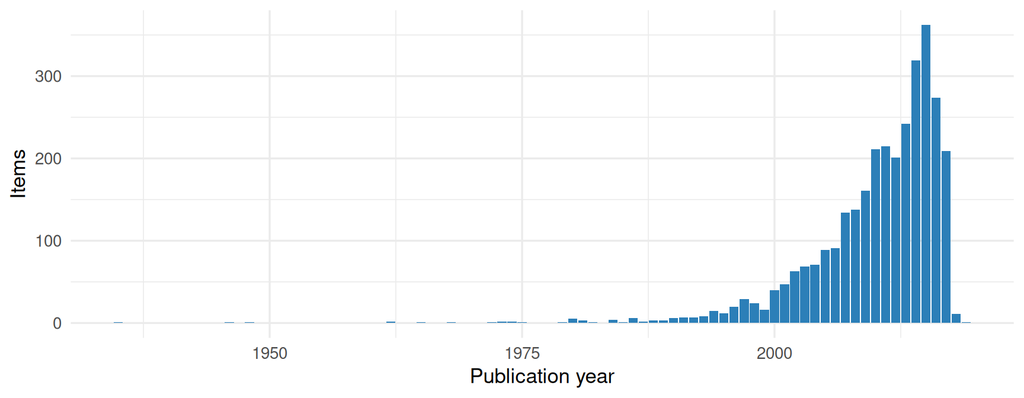

### Types of items

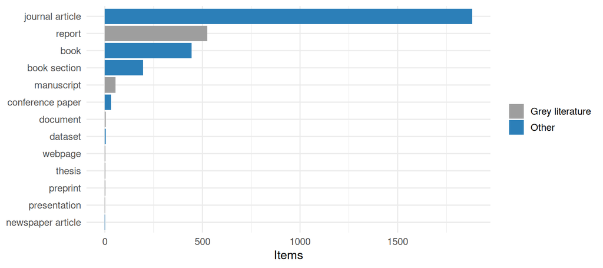

### Open access

Open access status of the publications found in OpenAlex. *Gold* and *diamond*: open in an open access journal; *hybrid*: open in a subscription journal; *green*: an open copy is in a repository; *bronze*: free to read on the publisher’s site; *closed*: not openly available.

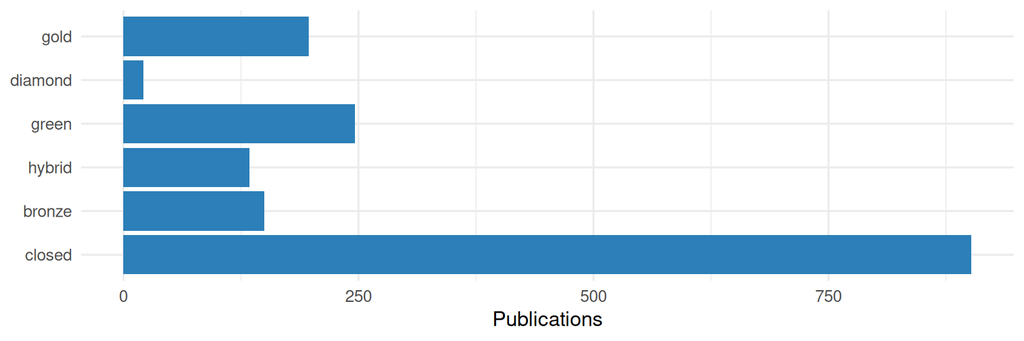

### Most frequent journals

| Journal | Items |
| --- | --- |
| Science | 49 |
| PLoS ONE | 46 |
| Biological Conservation | 43 |
| Marine Policy | 42 |
| Nature | 39 |
| Proceedings of the National Academy of Sciences | 27 |
| Biodiversity and Conservation | 24 |
| Conservation Biology | 23 |
| Global Change Biology | 22 |
| BioScience | 20 |

### Countries of the authors

Number of publications with at least one author from the country, for the publications found in OpenAlex.

| Country | Publications |
| --- | --- |
| United States | 563 |
| Australia | 369 |
| United Kingdom | 263 |
| China | 178 |
| Germany | 144 |
| Canada | 131 |
| Japan | 131 |
| France | 102 |
| India | 101 |
| Netherlands | 86 |
| Switzerland | 80 |
| New Zealand | 68 |
| Sweden | 61 |
| Italy | 56 |
| Singapore | 52 |

## How the checks work

**NoteDetails of the checks**

#### identifiers

##### DOI coverage (`met_id_doi`)

Number and share of items with a valid DOI, and items whose DOI field is filled but contains no valid DOI. DOIs are extracted with `openalexPro::extract_doi()` and lower cased.

##### ISBN coverage (`met_id_isbn`)

Number and share of items with an ISBN, overall and for the item types which should have one (`book`, `bookSection`).

##### ISSN coverage (`met_id_issn`)

Number and share of items with an ISSN, overall and for the item types which should have one (`journalArticle`, `magazineArticle`).

##### ISSN not in the standard form (`met_id_issn_form`)

Items whose ISSN field is not in the standard form: each ISSN as `1234-567X` (with hyphen, capital X), several separated by “,”. The ISSNs are checked with their check digit. If all are valid, the standard form is proposed; otherwise the item is listed with the ISSNs which are not valid.

##### DOIs in the wrong field (`met_id_doi_misplaced`)

Items with an empty DOI field but a DOI in the `Url` or `Extra` field. These DOIs are not used for the OpenAlex lookup and should be moved to the DOI field.

##### DOIs in the wrong form (`met_id_doi_form`)

Items whose DOI field contains a valid DOI, but not as a bare DOI: as a link (`https://doi.org/10.…`), with a prefix (`doi:`, `DOI`), URL-encoded (`%5B` for `[`) or with spaces or other characters around it. Citation styles add the link themselves, so a link in the DOI field appears twice in a bibliography. The bare DOI is the one recognised by `openalexPro::extract_doi()`, keeping its upper and lower case.

##### Items without identifier (`met_id_none`)

Items with none of DOI, ISBN, ISSN or Url. These items can neither be checked against OpenAlex nor easily be retrieved by readers.

##### DOIs found in OpenAlex for items without a DOI (`met_id_candidates`)

For items without a DOI, OpenAlex was searched by title (see [get_doi_candidates()]). The works found are compared with the item: title (ignoring case and punctuation), year and the surname of the first author. A work is a *likely* match if the titles are (nearly) the same (similarity at least 0.95), the years differ by at most 1 and the first authors have the same surname (year or author are not compared if the item has none), and the title has at least 4 words (short titles like “Zoonoses” are too general). It is a *possible* match if the titles are similar (at least 0.8). All likely and possible works with a DOI are kept, sorted per item, best first. DOIs used by another item in the group are noted (the item would be a duplicate).

#### metadata

##### Filled fields per item type (`met_meta_fields`)

Percentage of items with a filled field, per item type, for the main fields: Title, Author, Publication Year, Publication Title, Publisher, DOI, ISBN, ISSN, Url, Abstract Note and Language. Not every field is expected for every item type, e.g. reports have no Publication Title.

##### Problematic publication years (`met_meta_year`)

Items whose date is missing (`missing`), from whose date Zotero could not derive a year (`unparseable`), or whose year lies in the future (`future`).

##### Duplicate items (`met_meta_duplicates`)

Items which are in the group more than once, identified by the same DOI, or by the same normalised title (lower case, letters and digits only), publication year and first word of the first author.

##### Language not given as a standard code (`met_meta_language`)

Items whose language is not given as a standard language code, i.e. a two-letter ISO 639-1 code, optionally with a region (`en`, `en-US`), but e.g. as a name (`English`), a three-letter code (`eng`) or in a different spelling (`EN`, `en_us`). Citation styles and other tools only recognise the codes. Where the value is recognised, the standard code is proposed, based on the ISO 639-2 list (R package ISOcodes): codes, three-letter codes and the English names of the languages. Other values, e.g. names in the language itself, several languages or other text, are listed without a proposal.

#### openalex_check

##### Zotero DOIs found in OpenAlex (`met_check_found`)

Valid Zotero DOIs which were / were not found in OpenAlex. A DOI which is not found is either not indexed by OpenAlex or wrong.

##### Retracted works (`met_check_retracted`)

Works flagged as retracted by OpenAlex, with the key of the Zotero item(s) with the same DOI.

##### Wrong DOIs (`met_check_mismatch`)

Items whose DOI points in OpenAlex to a work with a different title or year, which usually means that the wrong DOI is attached to the item. An item is flagged when the title similarity (normalised Levenshtein distance) is below 0.8 or the years differ by more than one.

##### Item type agreement (`met_check_type`)

Zotero item type compared with the OpenAlex work type for items with the same DOI.

##### Missing dates found in OpenAlex (`met_check_date`)

Items without a date whose DOI was found in OpenAlex: the publication date in OpenAlex is proposed. OpenAlex gives 1 January when only the year is known, so such dates are proposed as the year only. Items whose DOI points to a different publication are left out.

##### Empty fields found in OpenAlex (`met_check_fill`)

Journal articles with an empty journal, volume, issue or pages field whose DOI was found in OpenAlex with these details: the values in OpenAlex are proposed. The journal is only taken if the publication is in a journal in OpenAlex (not e.g. a repository). Page ranges which end before they start (e.g. `1260-2`, shortened or wrong) are not proposed. Items whose DOI points to a different publication are left out.

##### OpenAlex ID in the Extra field (`met_check_openalex_id`)

Items whose DOI was found in OpenAlex, compared with the OpenAlex ID noted in their Extra field (a line `OpenAlex: W…`). Items without such a line can get it, which links them to OpenAlex for later checks. Items with a different ID are listed for checking: OpenAlex merges records, and the ID of a merged record redirects to the new one. Items whose DOI points to a different publication are left out.

##### OpenAlex ID in the Extra field not valid (`met_check_extra_id`)

Checks the lines `OpenAlex: …` in the Extra field (looked up by [get_extra_ids()]). A line is not valid if - it is not an OpenAlex work ID (`W` and digits), - the item has several lines with different IDs, - the ID is not in OpenAlex (wrong, or merged into another record), or - the work is a different publication: its DOI is not the DOI of the item, or, for items without DOI, its title is not similar (similarity below 0.8, see [title_similarity()]).

#### profile

##### Publication years (`met_prof_year`)

Number of items per publication year, with cumulative counts. Items without a year are counted as `NA`.

##### Open access status (`met_prof_oa`)

OpenAlex open access status (gold, diamond, green, hybrid, bronze, closed) of the works, overall and per publication year.

##### Top journals (`met_prof_journals`)

The 50 most frequent journals, from the Publication Title in Zotero and the source of the primary location in OpenAlex. Ties at rank 50 are included.

##### Author countries (`met_prof_countries`)

Number of works with at least one author affiliated with an institution in a country, per country (ISO 3166-1 alpha-2 codes from OpenAlex).

##### Item types and grey literature (`met_prof_types`)

Number of items per item type (Zotero) or work type (OpenAlex), and the share of grey literature, i.e. reports, theses, dissertations, web pages, documents, presentations, manuscripts, blog posts and preprints.

##### Languages (`met_prof_language`)

Languages as entered, and normalised to two letter codes (lower case, region removed, English spellings mapped to `en`). Inconsistent codes in the language as entered are a quality issue in themselves.

#### maintenance

##### Group activity (`met_maint_activity`)

Items added per month, and items added / modified in the 30 days before the metrics were calculated.

##### Items without tags (`met_maint_tags`)

Items without manual tags. Automatic tags, e.g. keywords imported from the publisher, are ignored.

IPBES Literature Report 0.4.0 · [source code on GitHub](https://github.com/IPBES-Data/IPBES.LiteratureReport) (© IPBES.LiteratureReport authors, [MIT licence](https://opensource.org/license/mit)) · reports and data on this website: [CC0 1.0](https://creativecommons.org/publicdomain/zero/1.0/) (no rights reserved)